# Local Moran’s I

- Show All Code
- Hide All Code
- View Source

Where are the clusters? Lung cancer in Pennsylvania

Author

Eric M. Delmelle · Lehigh University

## Where we left off

```r
library(sf)
library(dplyr)
library(ggplot2)
library(patchwork)
library(spdep)
library(SpatialEpi)   # pennLC

theme_set(theme_void(base_size = 12))
```

# 1 Data and weights (recap)

Same SIRs and queen-contiguity weights as last time, in one chunk.

```r
data(pennLC)
d <- pennLC$data

ref <- d |>
  group_by(race, gender, age) |>
  summarise(r = sum(cases) / sum(population), .groups = "drop")   # reference rates

county <- d |>
  left_join(ref, by = c("race", "gender", "age")) |>
  group_by(county) |>
  summarise(O = sum(cases), E = sum(population * r), .groups = "drop") |>
  mutate(SIR = O / E)

pa <- st_as_sf(pennLC$spatial.polygon) |>
  st_set_crs(4326) |>
  mutate(county = names(pennLC$spatial.polygon)) |>
  st_transform(5070) |>                                           # Albers
  left_join(county, by = "county")

nb <- poly2nb(pa, queen = TRUE)
lw <- nb2listw(nb, style = "W")                                   # row-standardized

sir_breaks <- c(0, 0.67, 0.83, 0.95, 1.05, 1.2, 1.5, Inf)
sir_fill   <- scale_fill_brewer(palette = "RdBu", direction = -1, drop = FALSE, name = "SIR")

moran.test(pa$SIR, lw)$estimate[1]                                # global I
```

```
Moran I statistic
      -0.01055968
```

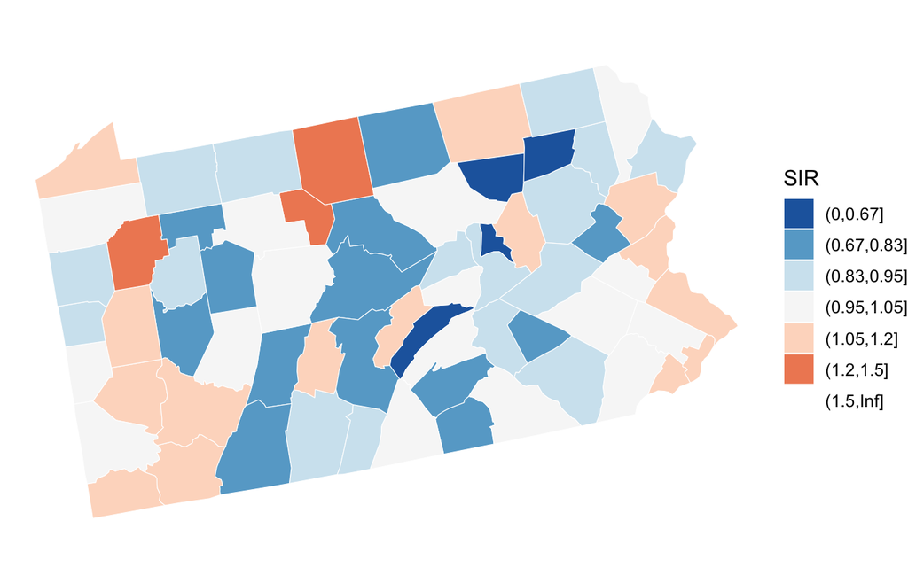

Figure 1: Lung cancer SIRs, Pennsylvania 2002.

```r
ggplot(pa) +
  geom_sf(aes(fill = cut(SIR, sir_breaks)), colour = "white", linewidth = 0.2) +
  sir_fill
```

# 2 From global to local

## 2.1 One number per county

Center the SIRs, $z_i = x_i - \bar x$. Global Moran’s I (row-standardized weights) is

$$I = \frac{\sum_i z_i \sum_j w_{ij} z_j}{\sum_i z_i^2}.$$

The numerator is a sum over counties. Pull out each county’s term and you get **local Moran’s I** (Anselin 1995):

$$I_i = \frac{z_i}{m_2} \sum_j w_{ij} z_j, \qquad m_2 = \frac{\sum_i z_i^2}{n}.$$

In words: **(my deviation) × (my neighbours’ average deviation)**, scaled by the variance. Averaging the $I_i$ gives back the global $I$.

| My SIR | Neighbours’ SIR | Sign of $I_i$ | Type |
| --- | --- | --- | --- |
| above mean | above mean | + | High-High |
| below mean | below mean | + | Low-Low |
| above mean | below mean | − | High-Low |
| below mean | above mean | − | Low-High |

## 2.2 Computing it

`localmoran_perm()` returns $I_i$, a $p$-value, and the quadrant for every county.

```r
set.seed(374)
lisa <- localmoran_perm(pa$SIR, lw, nsim = 999)

pa <- pa |>
  mutate(
    Ii    = lisa[, "Ii"],
    p_sim = lisa[, "Pr(z != E(Ii)) Sim"],                   # p-value
    quad  = as.character(attr(lisa, "quadr")$mean)          # quadrant
  )
```

# 3 The LISA cluster map

Colour significant counties by quadrant; everything else grey.

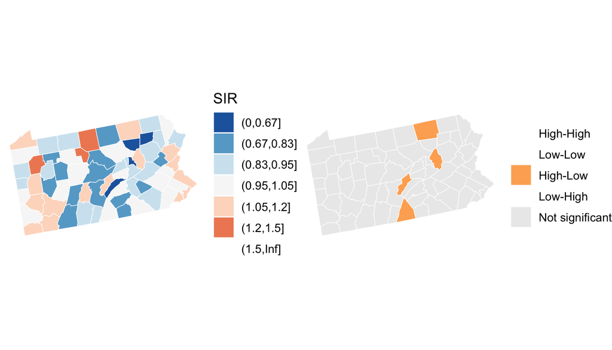

Figure 2: SIR (left) and LISA clusters at p < 0.05 (right).

```r
lisa_cols <- c("High-High" = "#d7191c", "Low-Low"  = "#2c7bb6",
               "High-Low"  = "#fdae61", "Low-High" = "#abd9e9",
               "Not significant" = "grey92")

pa <- pa |>
  mutate(cluster = factor(if_else(p_sim < 0.05, quad, "Not significant"),
                          levels = names(lisa_cols)))

m_sir <- ggplot(pa) +
  geom_sf(aes(fill = cut(SIR, sir_breaks)), colour = "white", linewidth = 0.2) +
  sir_fill

m_lisa <- ggplot(pa) +
  geom_sf(aes(fill = cluster), colour = "white", linewidth = 0.2) +
  scale_fill_manual(values = lisa_cols, drop = FALSE, name = NULL)

m_sir | m_lisa
```

```r
pa |>
  st_drop_geometry() |>
  filter(cluster != "Not significant") |>
  arrange(cluster, p_sim) |>
  transmute(county, cluster, O, E = round(E, 1),
            SIR = round(SIR, 2), Ii = round(Ii, 2), p_sim)
```

| county | cluster | O | E | SIR | Ii | p_sim |
| --- | --- | --- | --- | --- | --- | --- |
| franklin | High-Low | 105 | 109.9 | 0.96 | -0.12 | 0.030 |
| columbia | High-Low | 58 | 53.3 | 1.09 | -0.71 | 0.032 |
| mifflin | High-Low | 45 | 40.8 | 1.10 | -0.95 | 0.042 |
| bradford | High-Low | 59 | 53.2 | 1.11 | -0.89 | 0.048 |

## 3.1 Reading the map

- **High-High** (hot spot): high SIR, surrounded by high SIRs.
- **Low-Low** (cold spot): low SIR, surrounded by low SIRs.
- **High-Low / Low-High** (spatial outliers): a county that breaks from its surroundings.

Two cautions. A coloured county is the *core* of a local pattern; its neighbours are part of it even when they stay grey. And look at $E_i$ in the table: a county with few expected cases can produce an extreme SIR, and a “cluster” by chance. We return to how many counties we are testing at once next session.

# If you want to challenge yourself: build and read a LISA map

20 minutes.

1. Change the weights to the **four nearest neighbours**:

   ```r
   pts <- st_point_on_surface(st_geometry(pa))
   nb4 <- knn2nb(knearneigh(st_coordinates(pts), k = 4))
   lw4 <- nb2listw(nb4, style = "W")
   ```

   Rerun `localmoran_perm()` with `lw4` (same seed) and redraw the LISA map. Which counties keep their label? Which change?
2. Pick one High-High county. Report its SIR, $E_i$, and the SIRs of its neighbours. Does the label make sense to you?
3. In one sentence for a county health officer, explain what a Low-High outlier means.

# Key takeaways

1. Local Moran’s I splits global I into one value per county: own deviation × neighbours’ average deviation.
2. Positive $I_i$: like the neighbours (High-High, Low-Low). Negative $I_i$: unlike them (High-Low, Low-High).
3. The LISA map combines type and significance; read it alongside $E_i$ and the choice of neighbours.

# References

Anselin, L. (1995). Local indicators of spatial association—LISA. *Geographical Analysis*, 27(2), 93–115.

Rogerson, P., & Yamada, I. (2009). *Statistical detection and surveillance of geographic clusters*. Chapman & Hall/CRC, Ch. 4.